# Gabitto split into two donor-disjoint halves, twice: the donor-level regression `donor_wls` replicates best, `state_adjusted` has the lowest replicate score and no signal that replicates, and a fifth to a third of eSVD-DE’s calls change sign in the other half

Kevin Z. Lin (drafted by Claude)

2026-11-15

# 1 Overview

This document is built from Kevin’s note of 2026-11-15 (`2026-11-15_autoresearch-gabitto-replicate.txt`), from the two autoresearch loops on the reported log fold change and its standard error and the study that followed them (`2026-11-12_autoresearch_beyond-score_claude.Rmd`), from Tati’s Writeup45 fit of the Gabitto cohort (the design), and from Writeup49 (the split-half and winner’s-curse conventions). Everything before this document was scored on simulated cohorts with a known truth. Here the Gabitto microglia are split into two halves that share no donor, each half is fitted by eSVD-DE on its own, and every rule is asked how well its logFC and SE from one half agree with those from the other. The split is done twice.

**The question.** On a real cohort, which rule’s log2 fold change and SE replicate best between two independent halves: by the replicate analogue of the autoresearch score, by the correlation of the logFC over the genes that at least one half nominates as differentially expressed, and by whether a nominated gene keeps the sign of its logFC in the other half?

What the document argues:

1. **The four fits are comparable and each took under 45 minutes.** Each half has 40 donors (13 or 14 controls) and about 20,000 nuclei; the package’s test calls 167 to 280 genes per half at 5% FDR, and pseudobulk DESeq2 calls 4 to 29 (section 2.1).
2. **`state_adjusted` has the lowest replicate score and its logFC do not replicate.** Its score is -0.58 and -0.65 nats per gene, well below every other rule, while its two halves correlate at 0.00 and 0.00 and a gene nominated by eSVD-DE’s test keeps its sign in the other half 50% and 53% of the time. The rule’s logFC have half the spread of the other rules’ and an SE that matches that spread, which a score without a truth rewards (section 4.1).
3. **Among the rules that keep a signal, the `donor_wls` family has the lowest score in both splits**, -0.22 and -0.26 for `donor_wls@esvd_nofloor` against -0.14 and -0.22 for `deseq2` and 0.47 and 0.49 for `stored`, and it is also first on the score against the other half’s DESeq2 (section 4.2).
4. **On the genes eSVD-DE’s test nominates, the `donor_wls` family and the `raw` family correlate best between the halves** (`donor_wls`: 0.55 and 0.64; `raw`: 0.61 and 0.51; `stored`: 0.51 and 0.46; `deseq2`: 0.47 and 0.54), and `donor_wls` is the more stable of the two across the splits (section 4.3).
5. **The SE of `stored` is about 2.5 times the disagreement between the halves, and the SE of `donor_wls` is about 10% above it** (`z_rms` 0.38 and 0.43 and 0.89 and 0.85; 1 is calibrated). `raw` and `deseq2` are closest to 1, and `null_rescaled` is too small for the genes whose nuisance rate is at the cap (section 4.4).
6. **A gene that eSVD-DE’s test calls in one half keeps the sign of its logFC in the other half 81% and 66% of the time in the two splits**, whichever rule supplies the logFC. The calls that change sign are concentrated among the genes at the nuisance cap and among the calls that `donor_wls` does not support at nominal $p < 0.05$, clearly in the second split and weakly in the first (section 4.5).
7. **The recommendation of the beyond-score study stands on real data**: report the pair from `donor_wls@esvd_nofloor`, do not use `state_adjusted` at the default rank on a cohort of this size, and read an eSVD-DE call together with the `donor_wls` interval. The bank needs examples where the rank is close to the number of donors, and the scorer needs a gate on retained signal (section 5).

*How to read.* The blue box says how the cohort was split; green boxes close each results subsection with what it changes; the orange box in section 5 is the procedure. A reader of the boxes alone has the argument.

| Stage | What it does | Section |
| --- | --- | --- |
| Definitions | the cohort, the two splits, the four fits, the rules, the statistics | 2 |
| Each rule | the two halves against each other, one subsection per rule | 3 |
| Side by side | the score, the correlation, the SE, the sign of the nominated genes | 4 |
| Recommendation | the rule to report from and what the bank should add | 5 |

# 2 Definitions

## 2.1 The cohort and the two splits

The data are the microglia of the SEA-AD cohort of Gabitto et al. (2024) as cleaned for the Was2CoDE analysis (`Writeup43_gabitto_cleaned_only-counts.RData`): 41,187 nuclei of 80 donors and 5,256 genes. A donor is a case when `CERAD_binary` is `Case` (53 donors) and a control otherwise (27 donors), the definition of Tati’s Writeup45 fit of the whole cohort.

The 80 donors fall into eight strata of CERAD arm, sex and APOE4 status. Within each stratum the donors are permuted and dealt alternately to two halves, and the half that receives the first donor alternates over the strata with an odd count so that the leftover donors do not all land in one half. A donor is therefore in exactly one half of a split. The procedure is run twice with different seeds (`split1`, seed 10; `split2`, seed 20), and 46 of the 80 donors keep their half label between the two splits. Each of the four halves is then fitted on its own with `eSVD2::eSVD_helper()` of version 1.2.0 at the settings of Writeup45: `k = 30`, covariates `sex`, `APOE4status`, `PMI` and `Ageatdeath`, every other argument at its default.

Table 1. The donors of each half, by arm. PMI and age at death were not stratified on.

| split | half | arm | num_donors | num_cells | num_female | num_apoe4 | mean_pmi | mean_age |
| --- | --- | --- | --- | --- | --- | --- | --- | --- |
| split1 | 1 | Control | 13 | 6439 | 7 | 1 | 7.40 | 83.62 |
| split1 | 1 | Case | 27 | 14102 | 16 | 10 | 6.80 | 87.41 |
| split1 | 2 | Control | 14 | 7180 | 8 | 2 | 6.83 | 87.86 |
| split1 | 2 | Case | 26 | 13466 | 17 | 10 | 7.04 | 86.19 |
| split2 | 1 | Control | 14 | 7448 | 8 | 2 | 7.81 | 84.64 |
| split2 | 1 | Case | 26 | 14540 | 16 | 10 | 6.90 | 86.81 |
| split2 | 2 | Control | 13 | 6171 | 7 | 1 | 6.35 | 87.08 |
| split2 | 2 | Case | 27 | 13028 | 17 | 10 | 6.93 | 86.81 |

Table 2. The four fits. `null_mean` and `null_sd` are the empirical null of the package’s test; `share_capped` is the share of genes whose nuisance rate sits at the cap; the last two columns count the genes called at 5% FDR by the package’s test and by pseudobulk DESeq2.

| fit | num_case | num_control | num_cells | num_genes | fit_minutes | null_mean | null_sd | share_capped | num_esvd_deg | num_deseq2_deg |
| --- | --- | --- | --- | --- | --- | --- | --- | --- | --- | --- |
| split1_half1 | 27 | 13 | 20541 | 5256 | 36 | -0.03 | 0.33 | 0.17 | 213 | 9 |
| split1_half2 | 26 | 14 | 20646 | 5256 | 37 | -0.09 | 0.36 | 0.17 | 240 | 29 |
| split2_half1 | 26 | 14 | 21988 | 5256 | 40 | -0.08 | 0.34 | 0.17 | 167 | 4 |
| split2_half2 | 27 | 13 | 19199 | 5256 | 35 | -0.08 | 0.39 | 0.17 | 280 | 7 |

## 2.2 The rules

Every rule is the file the loops left, unedited, applied as in the beyond-score study (`2026-11-12_autoresearch_beyond-score_claude.Rmd`, section 2.2).

| Name in the tables | Rule | Reads of the fit |
| --- | --- | --- |
| `stored` | what 1.2.0 reports: log ratio of the arms’ mean posterior, SE from the posterior’s mixture variances | posterior |
| `null_rescaled` | `stored`, the logFC shifted by the empirical null’s mean and the SE multiplied by its SD | posterior, empirical null |
| `deshrunk` | `stored`’s logFC; between-donor SE of the posterior donor means divided by the shrinkage weight | posterior, library, nuisance rate |
| `raw` | ratio of the arms’ means of donor means of $A/\ell$, delta-method SE between donors | library |
| `raw_null` | `raw` with the empirical null’s shift and rescaling | library |
| `donor_wls` | weighted regression of $\log\{(y_{dg} + 1/2)/L_{dg}\}$ on the arm and the donor-level covariates, residual variance moderated across genes, logFC shifted by the null’s mean | library |
| `gap_trend` | as `donor_wls` with voom-style weights and a variance trend in a covariate that contains the between-arm gap | library |
| `embed_prior` | `donor_wls` with the embedding’s predicted donor variance in the moderation prior | library, embedding |
| `state_adjusted` | `donor_wls` on summaries with the embedding’s donor offset removed; the arm coefficients’ component along the loadings subtracted | library, embedding |
| `deseq2` | DESeq2 on donor pseudobulk; design: sex, APOE4 status, PMI, age at death and the arm | nothing |

Here $y_{dg}$ is the donor’s summed count and $L_{dg}$ its summed library. A suffix names the library a library-reading rule was handed in place of the fitted one: `@esvd_nofloor` (the fitted library before the posterior’s floor at 0.1), `@esvd_depth` (the fitted intercept and depth alone), `@total` (the cell’s summed counts), `@sf` and `@tmm` (summed counts rescaled to DESeq2’s size factors or edgeR’s TMM factors of the donor pseudobulk). Every covariate of this design is constant within a donor, so the `_cov` variants of the beyond-score study coincide with the plain ones. `raw@esvd_nofloor` and `raw@total` were added on 2026-11-16 for the Green study (`../2026-11-16_green/`), which compares `raw` and `donor_wls` on one library; they appear in the tables and figures of section 4 and no number of the other methods changed.

## 2.3 What is compared between the two halves

For one rule and one split, gene $g$ has the pair $(\widehat{\beta}_{g1}, s_{g1})$ from half 1 and $(\widehat{\beta}_{g2}, s_{g2})$ from half 2, on the $\log_2$ scale. The two halves share no donor, so the two estimates are independent given the population’s effect.

**The replicate score.** The autoresearch score is the Gaussian negative log-likelihood of the true effect under $N(\widehat{\beta}_g, s_g^2)$. A real cohort has no known truth, and the other half takes its place: if both halves estimate one effect and both SEs are honest, the difference $\widehat{\beta}_{g1} - \widehat{\beta}_{g2}$ is $N(0, s_{g1}^2 + s_{g2}^2)$, and the score is

$$\text{score} = \frac{1}{p}\sum_{g=1}^{p}
\left[\tfrac{1}{2}\log\{2\pi (s_{g1}^2 + s_{g2}^2)\} +
\frac{(\widehat{\beta}_{g1} - \widehat{\beta}_{g2})^2}{2 (s_{g1}^2 +
s_{g2}^2)}\right],$$

in nats per gene, lower being better. It rewards estimates that agree and SEs that match the size of the disagreement. The companion calibration number is the root mean square of $(\widehat{\beta}_{g1} - \widehat{\beta}_{g2}) / \sqrt{s_{g1}^2 + s_{g2}^2}$ (`z_rms`), which is 1 when the SEs explain the disagreement and above 1 when they are too small. The replicate score differs from the autoresearch score in one respect that matters for reading it: a bias that the two halves share (a depth artifact, shrinkage toward a common value) cancels in the difference, so the replicate score cannot see it.

**The score against a common target.** To give every rule the same target, each rule’s pair from one half is also scored against the *other* half’s pseudobulk DESeq2 estimate, the difference having variance $s_{g}^2$ plus DESeq2’s squared SE, averaged over the two directions (`score_cross`). A rule cannot lower this number through a bias its own two halves share, and the comparison favours DESeq2’s estimand (the marginal effect on summed counts).

**Nominated genes.** A gene is nominated when it is called at 5% FDR in at least one half, under three definitions: by eSVD-DE’s own test (the package’s `fdr_vec`; the same genes for every rule), by pseudobulk DESeq2 (`padj`; the same genes for every rule), and by the rule’s own Wald test, $z = \widehat{\beta}_g / s_g$ against the standard normal with BH over the half’s genes (a different gene set per rule, whose size is reported).

**Statistics on the nominated genes.** The Pearson correlation of $\widehat{\beta}_{g1}$ and $\widehat{\beta}_{g2}$ over the nominated genes; the share of discoveries whose logFC has the same sign in the other half (`sign_rep`, each discovery counted from its discovering half); and the replication slope (`slope_rep`), the least-squares line through the origin of the replication half’s logFC on the discovering half’s, the convention of Writeup49. A slope of 1 means the discovered effects reappear at full size, and the winner’s curse puts it below 1.

# 3 Each rule between the two halves

Each subsection shows one rule. The upper figure has every gene, coloured by the half whose Wald test of the rule’s own pair nominates it; the lower figure has only the genes that eSVD-DE’s test nominates in at least one half, the same genes in every subsection. The dashed line is the diagonal, and a gene beyond the axes is drawn on the edge.

## 3.1 `stored`

Over all 5256 genes the replicate score of `stored` is 0.47 and 0.49 nats per gene in the two splits with `z_rms` 0.38 and 0.43, and the two halves’ logFC correlate at 0.40 and 0.37. Its own Wald test nominates 2 and 0 genes in at least one half, of which 0 and 0 in both halves.

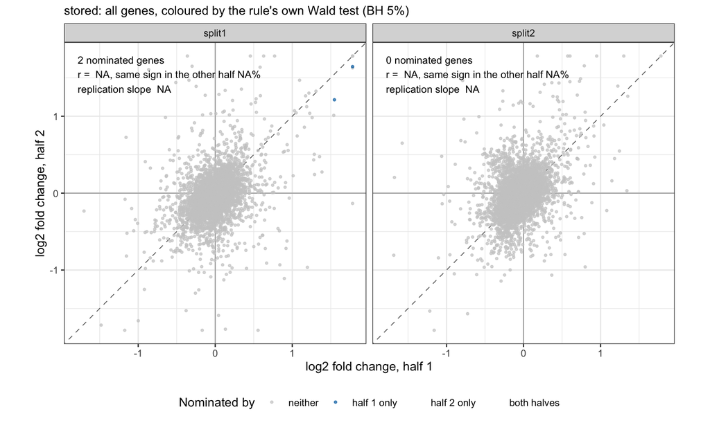

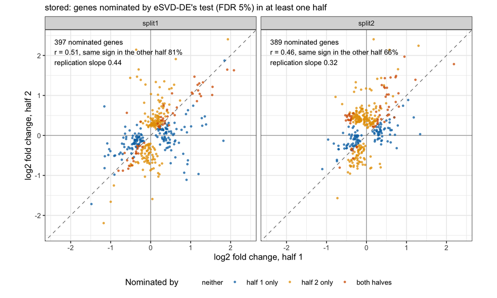

| split | score | z_rms | r_all | score_cross | own_genes | own_both | own_r | own_sign | own_slope | esvd_r | esvd_sign | esvd_slope |
| --- | --- | --- | --- | --- | --- | --- | --- | --- | --- | --- | --- | --- |
| split1 | 0.47 | 0.38 | 0.40 | 0.27 | 2 | 0 | NA | NA | NA | 0.51 | 0.81 | 0.44 |
| split2 | 0.49 | 0.43 | 0.37 | 0.28 | 0 | 0 | NA | NA | NA | 0.46 | 0.66 | 0.32 |

## 3.2 `null_rescaled`

Over all 5256 genes the replicate score of `null_rescaled` is -0.06 and 0.09 nats per gene in the two splits with `z_rms` 1.09 and 1.18, and the two halves’ logFC correlate at 0.40 and 0.39. Its own Wald test nominates 434 and 451 genes in at least one half, of which 68 and 70 in both halves.

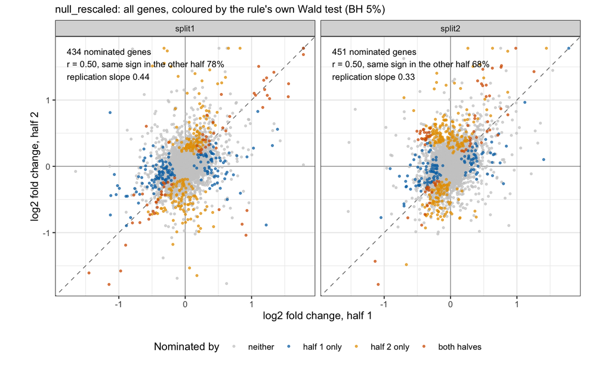

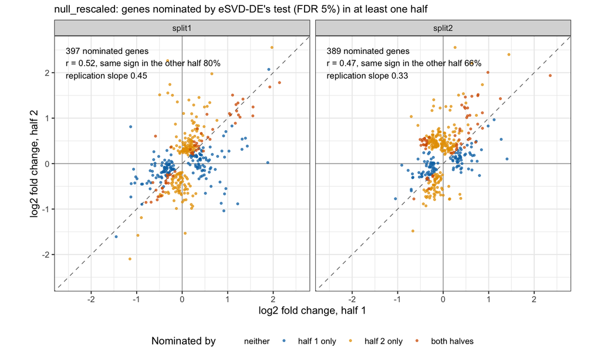

| split | score | z_rms | r_all | score_cross | own_genes | own_both | own_r | own_sign | own_slope | esvd_r | esvd_sign | esvd_slope |
| --- | --- | --- | --- | --- | --- | --- | --- | --- | --- | --- | --- | --- |
| split1 | -0.06 | 1.09 | 0.40 | -0.14 | 434 | 68 | 0.5 | 0.78 | 0.44 | 0.52 | 0.80 | 0.45 |
| split2 | 0.09 | 1.18 | 0.39 | -0.13 | 451 | 70 | 0.5 | 0.68 | 0.33 | 0.47 | 0.66 | 0.33 |

## 3.3 `deshrunk`

Over all 5256 genes the replicate score of `deshrunk` is 0.61 and 0.61 nats per gene in the two splits with `z_rms` 0.38 and 0.36, and the two halves’ logFC correlate at 0.40 and 0.37. Its own Wald test nominates 1 and 1 genes in at least one half, of which 0 and 0 in both halves.

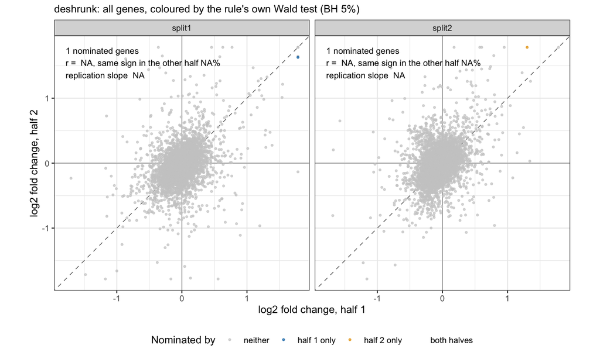

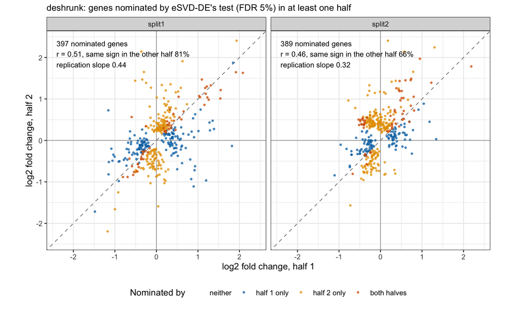

| split | score | z_rms | r_all | score_cross | own_genes | own_both | own_r | own_sign | own_slope | esvd_r | esvd_sign | esvd_slope |
| --- | --- | --- | --- | --- | --- | --- | --- | --- | --- | --- | --- | --- |
| split1 | 0.61 | 0.38 | 0.40 | 0.39 | 1 | 0 | NA | NA | NA | 0.51 | 0.81 | 0.44 |
| split2 | 0.61 | 0.36 | 0.37 | 0.36 | 1 | 0 | NA | NA | NA | 0.46 | 0.66 | 0.32 |

## 3.4 `raw`

Over all 5256 genes the replicate score of `raw` is -0.16 and -0.19 nats per gene in the two splits with `z_rms` 1.03 and 1.00, and the two halves’ logFC correlate at 0.43 and 0.37. Its own Wald test nominates 217 and 152 genes in at least one half, of which 11 and 3 in both halves.

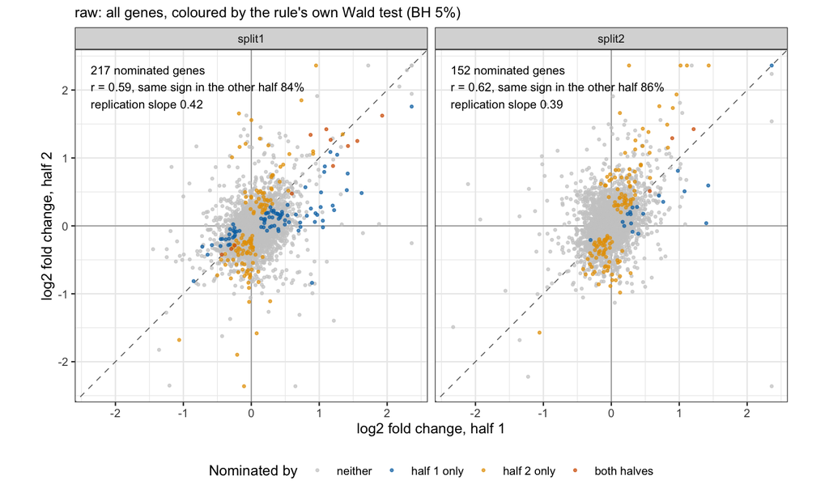

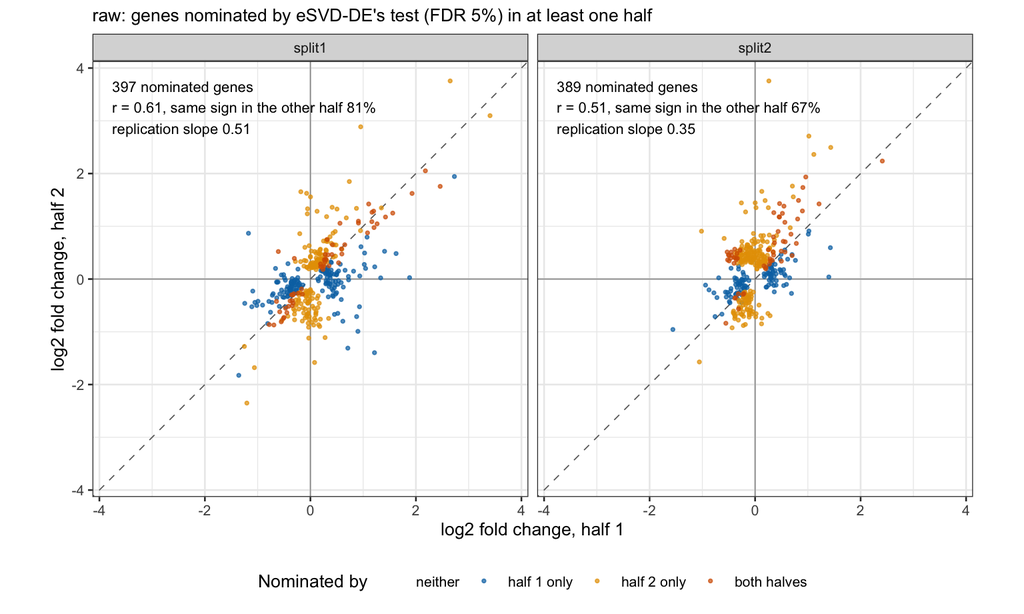

| split | score | z_rms | r_all | score_cross | own_genes | own_both | own_r | own_sign | own_slope | esvd_r | esvd_sign | esvd_slope |
| --- | --- | --- | --- | --- | --- | --- | --- | --- | --- | --- | --- | --- |
| split1 | -0.16 | 1.03 | 0.43 | -0.14 | 217 | 11 | 0.59 | 0.84 | 0.42 | 0.61 | 0.81 | 0.51 |
| split2 | -0.19 | 1.00 | 0.37 | -0.18 | 152 | 3 | 0.62 | 0.86 | 0.39 | 0.51 | 0.67 | 0.35 |

## 3.5 `raw_null`

Over all 5256 genes the replicate score of `raw_null` is -0.15 and -0.12 nats per gene in the two splits with `z_rms` 0.78 and 0.74, and the two halves’ logFC correlate at 0.44 and 0.39. Its own Wald test nominates 7 and 3 genes in at least one half, of which 0 and 0 in both halves.

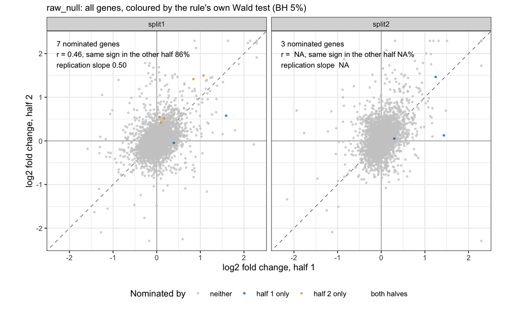

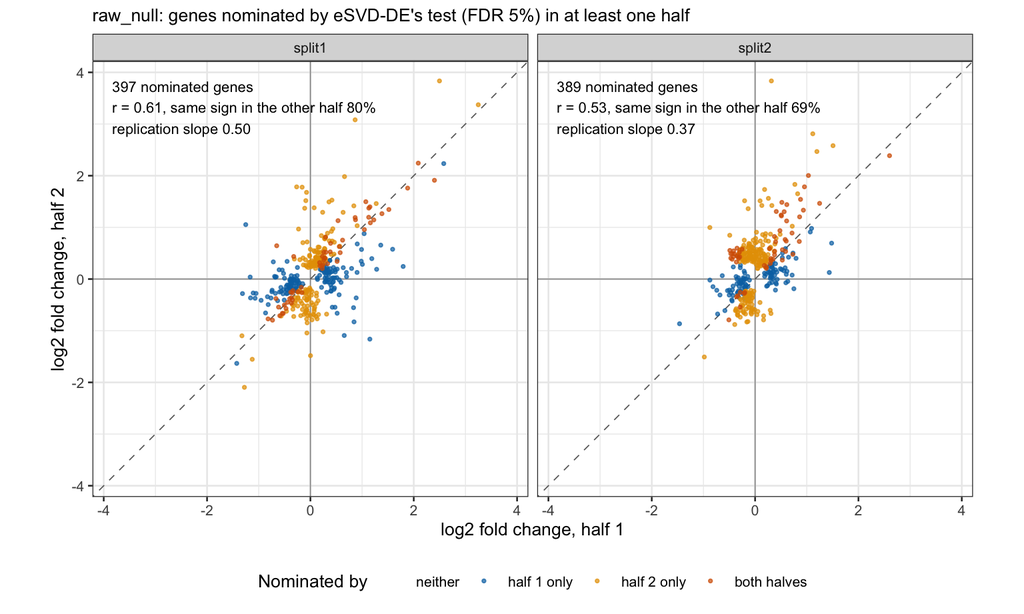

| split | score | z_rms | r_all | score_cross | own_genes | own_both | own_r | own_sign | own_slope | esvd_r | esvd_sign | esvd_slope |
| --- | --- | --- | --- | --- | --- | --- | --- | --- | --- | --- | --- | --- |
| split1 | -0.15 | 0.78 | 0.44 | -0.14 | 7 | 0 | 0.46 | 0.86 | 0.5 | 0.61 | 0.80 | 0.50 |
| split2 | -0.12 | 0.74 | 0.39 | -0.15 | 3 | 0 | NA | NA | NA | 0.53 | 0.69 | 0.37 |

## 3.6 `donor_wls`

Over all 5256 genes the replicate score of `donor_wls` is -0.17 and -0.26 nats per gene in the two splits with `z_rms` 0.94 and 0.85, and the two halves’ logFC correlate at 0.38 and 0.50. Its own Wald test nominates 21 and 2 genes in at least one half, of which 0 and 0 in both halves.

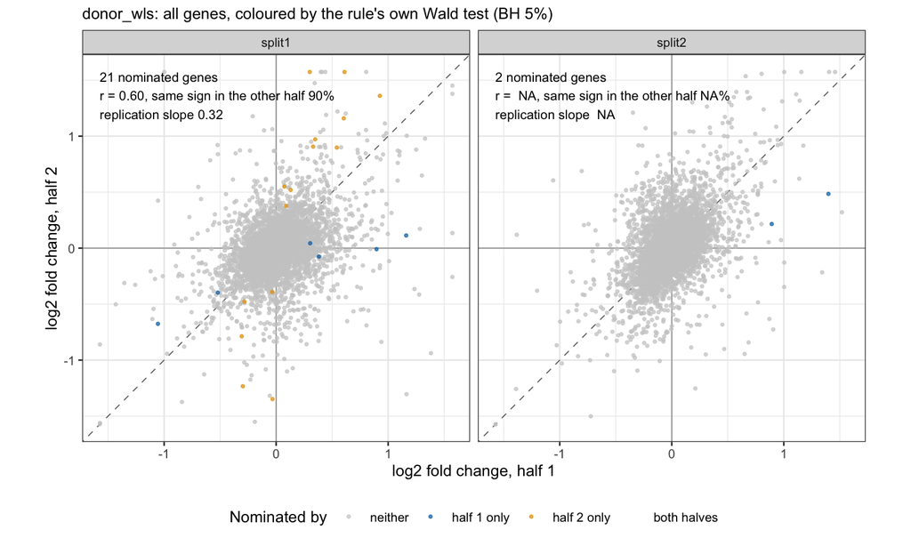

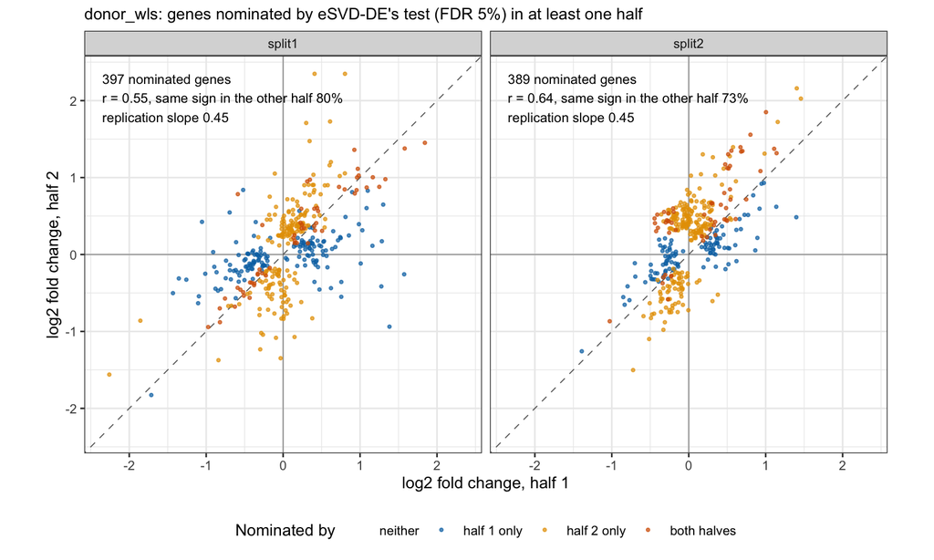

| split | score | z_rms | r_all | score_cross | own_genes | own_both | own_r | own_sign | own_slope | esvd_r | esvd_sign | esvd_slope |
| --- | --- | --- | --- | --- | --- | --- | --- | --- | --- | --- | --- | --- |
| split1 | -0.17 | 0.94 | 0.38 | -0.16 | 21 | 0 | 0.6 | 0.9 | 0.32 | 0.55 | 0.80 | 0.45 |
| split2 | -0.26 | 0.85 | 0.50 | -0.23 | 2 | 0 | NA | NA | NA | 0.64 | 0.73 | 0.45 |

## 3.7 `gap_trend`

Over all 5256 genes the replicate score of `gap_trend` is -0.14 and -0.20 nats per gene in the two splits with `z_rms` 0.93 and 0.89, and the two halves’ logFC correlate at 0.39 and 0.52. Its own Wald test nominates 60 and 32 genes in at least one half, of which 4 and 3 in both halves.

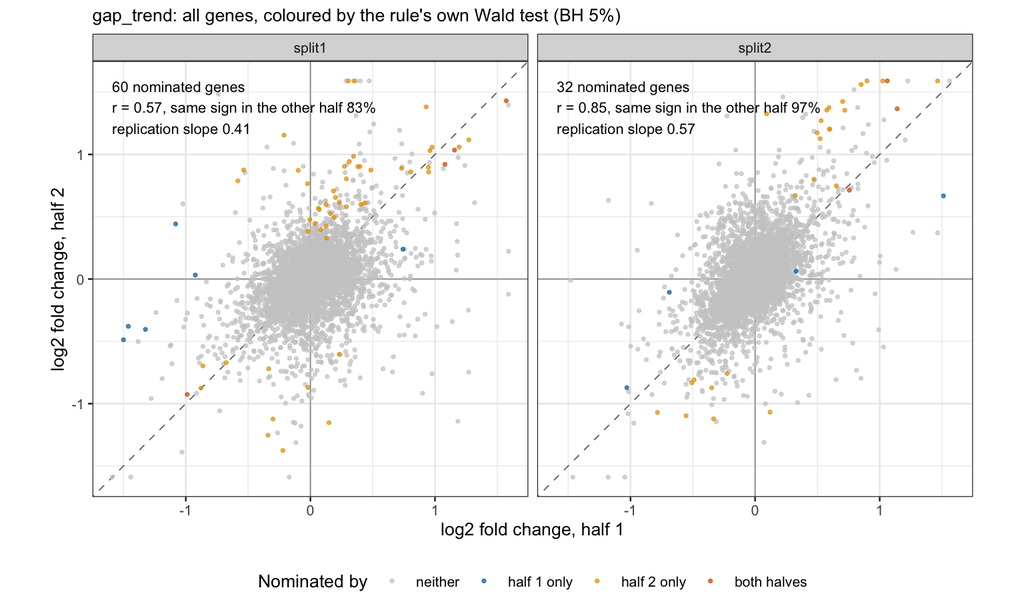

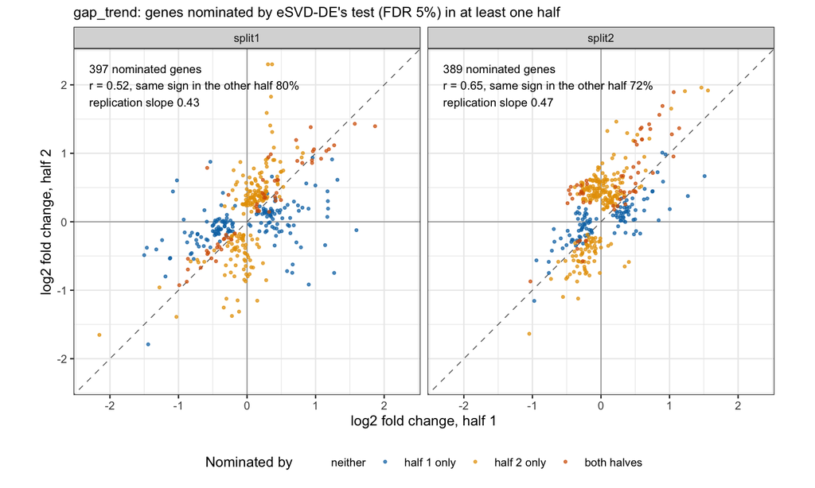

[output not shown]

## 3.8 `embed_prior`

Over all 5256 genes the replicate score of `embed_prior` is -0.17 and -0.26 nats per gene in the two splits with `z_rms` 0.93 and 0.85, and the two halves’ logFC correlate at 0.38 and 0.50. Its own Wald test nominates 4 and 0 genes in at least one half, of which 0 and 0 in both halves.

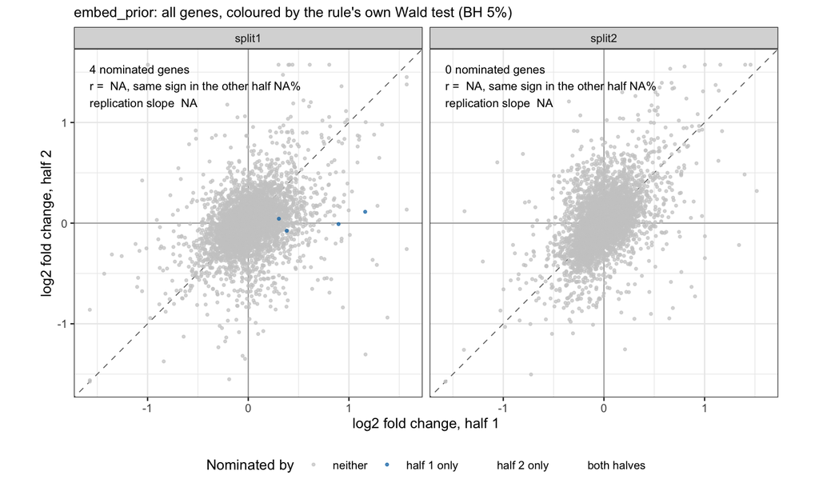

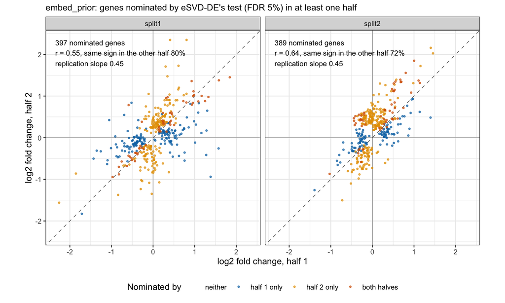

| split | score | z_rms | r_all | score_cross | own_genes | own_both | own_r | own_sign | own_slope | esvd_r | esvd_sign | esvd_slope |
| --- | --- | --- | --- | --- | --- | --- | --- | --- | --- | --- | --- | --- |
| split1 | -0.17 | 0.93 | 0.38 | -0.16 | 4 | 0 | NA | NA | NA | 0.55 | 0.80 | 0.45 |
| split2 | -0.26 | 0.85 | 0.50 | -0.23 | 0 | 0 | NA | NA | NA | 0.64 | 0.72 | 0.45 |

## 3.9 `state_adjusted`

Over all 5256 genes the replicate score of `state_adjusted` is -0.58 and -0.65 nats per gene in the two splits with `z_rms` 1.05 and 1.00, and the two halves’ logFC correlate at 0.00 and 0.00. Its own Wald test nominates 13 and 4 genes in at least one half, of which 0 and 0 in both halves.

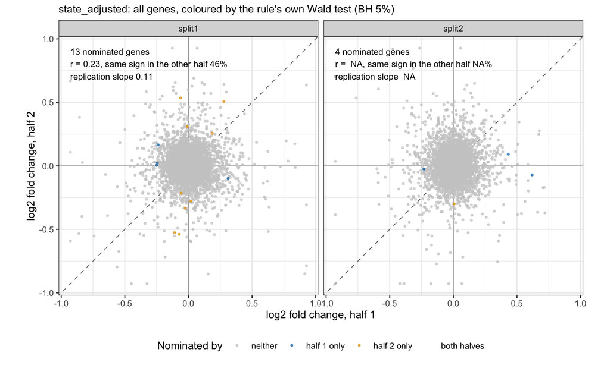

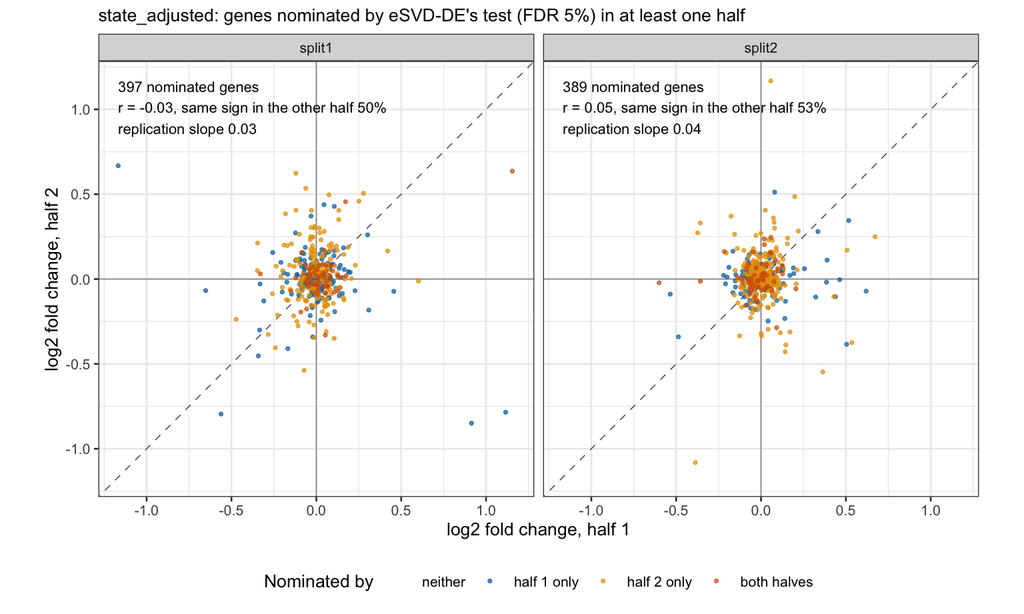

| split | score | z_rms | r_all | score_cross | own_genes | own_both | own_r | own_sign | own_slope | esvd_r | esvd_sign | esvd_slope |
| --- | --- | --- | --- | --- | --- | --- | --- | --- | --- | --- | --- | --- |
| split1 | -0.58 | 1.05 | 0 | -0.06 | 13 | 0 | 0.23 | 0.46 | 0.11 | -0.03 | 0.50 | 0.03 |
| split2 | -0.65 | 1.00 | 0 | -0.13 | 4 | 0 | NA | NA | NA | 0.05 | 0.53 | 0.04 |

## 3.10 `donor_wls@esvd_nofloor`

Over all 5256 genes the replicate score of `donor_wls@esvd_nofloor` is -0.22 and -0.26 nats per gene in the two splits with `z_rms` 0.89 and 0.85, and the two halves’ logFC correlate at 0.39 and 0.49. Its own Wald test nominates 4 and 1 genes in at least one half, of which 0 and 0 in both halves.

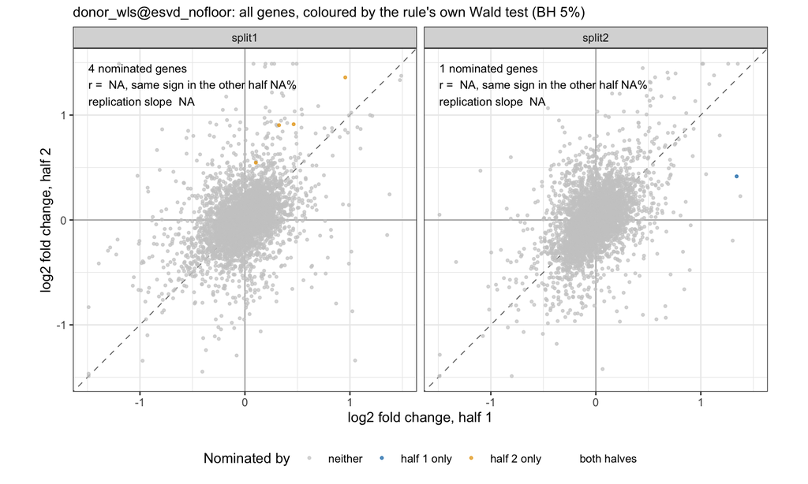

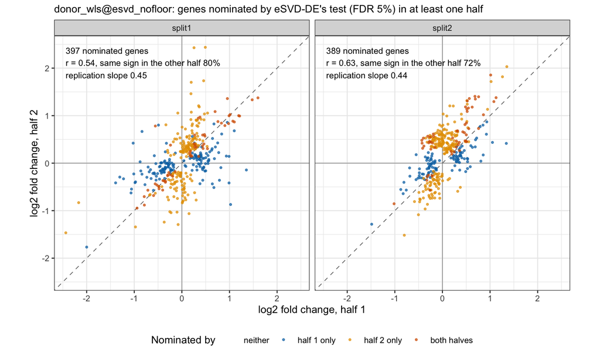

| split | score | z_rms | r_all | score_cross | own_genes | own_both | own_r | own_sign | own_slope | esvd_r | esvd_sign | esvd_slope |
| --- | --- | --- | --- | --- | --- | --- | --- | --- | --- | --- | --- | --- |
| split1 | -0.22 | 0.89 | 0.39 | -0.17 | 4 | 0 | NA | NA | NA | 0.54 | 0.80 | 0.45 |
| split2 | -0.26 | 0.85 | 0.49 | -0.24 | 1 | 0 | NA | NA | NA | 0.63 | 0.72 | 0.44 |